# Exploring the BRFSS data

## Setup

### Load packages

```r
library(ggplot2)
library(dplyr)
```

### Load data

Make sure your data and R Markdown files are in the same directory. When loaded your data file will be called `brfss2013`. Delete this note when before you submit your work.

```r
load("~/R/Projects/Learning R/brfss2013.RData")
```

## Part 1: Data

he Behavioral Risk Factor Surveillance System (BRFSS) is a collaborative project between all of the states in the United States (US) and participating US territories and the Centers for Disease Control and Prevention (CDC). The BRFSS is administered and supported by CDC’s Population Health Surveillance Branch, under the Division of Population Health at the National Center for Chronic Disease Prevention and Health Promotion. BRFSS is an ongoing surveillance system designed to measure behavioral risk factors for the non-institutionalized adult population (18 years of age and older) residing in the US. The BRFSS was initiated in 1984, with 15 states collecting surveillance data on risk behaviors through monthly telephone interviews. Over time, the number of states participating in the survey increased; by 2001, 50 states, the District of Columbia, Puerto Rico, Guam, and the US Virgin Islands were participating in the BRFSS. Today, all 50 states, the District of Columbia, Puerto Rico, and Guam collect data annually and American Samoa, Federated States of Micronesia, and Palau collect survey data over a limited point- in-time (usually one to three months). In this document, the term “state” is used to refer to all areas participating in BRFSS, including the District of Columbia, Guam, and the Commonwealth of Puerto Rico.

Data Gathering Year: 2013 Data Gathering Location: US states and the District of Columbia, Puerto Rico, and Guam Population in Focus: non-institutionalized adult population, aged 18 years or older, who reside in the US.

The Data Gathering Method: - Stratified Random sampling - state-specific data

Data Gathering Goals: - study preventive health practices - Study risk behaviors that are linked to chronic diseases, injuries, and preventable infectious diseases that affect the adult population

Study Type: - Observational Study

Generalization & Causality: - The results can be generalized to the adult population of the participating states. - Results must be investigated for implicit biases - This Study is based on Observational Study and Causal Inferences cannot be drawn from data.

## Part 2: Research questions

**Research question 1:** General Health and Employment

Is there any relationship between People’s General Health (Genhlth) and their work (employ1) in the population of interest?

Why I am interested in this Question:

The first thing that comes to my mind is that having a job and dedicating a great portion of your time will enable you to be busy with matter not related to you and consequently, have more physical and mental activity, at the same time, have more relationships. I need also mention that being busy with something as a job, will give you goals, both short-term and long-term, while your income will allow you to be more confident and self-reliant, which is a positive feeling for many people.

So, in order to address this question, I analyzed 3 variables : employ1, genhlth, sex. Considering “Sex” helps me to compare the results in both sex and see if there is any relation with employment status and people’s sex.

Hypothesis: I guess that people with no job or less hours of work feel less healthy.

**Research question 2:**

General Health and States

Is there any relation between that location of the poeple and their general health?

Why I am interested in this Question:

The other thing that brings to my mind about General Health is people’s location. As our environment has huge effects on our health and what we understand as health. At the same time, the distribution of facilities can vary in different states, which can affect people’s general health, as their access to Health Care services or other related facilities can largely be depended on that.

So, in order to address this question, I analyzed 3 variables : X_state, genhlth, sex.

Hypothesis: I guess people’s General Health must have relations with their location (State).

**Research question 3:**

General Health and Education

How education can affect general health of the population in focus of this study?

Why I am interested in this Question:

Like the previous questions, I am interested to study the effects of different parameters on the General Health. So, in this question, I am going to address the effects of education on the Geneal Health. On the other hand, higher education increases the chance of people to have access to higher income level and consequently have more purchasing power and access to high-quality and more expensive health care services.

So, in order to address this question, I analyzed 3 variables : educa, genhlth, sex.

Hypothesis: I guess people’s General Health must have relations with their education.

## Part 3: Exploratory data analysis

NOTE: Insert code chunks as needed by clicking on the “Insert a new code chunk” button (green button with orange arrow) above. Make sure that your code is visible in the project you submit. Delete this note when before you submit your work.

**Research question 1:**

```r
q1 <- brfss2013 %>% select(sex, employ1, genhlth) %>%
  filter(!is.na(sex), !is.na(employ1),!is.na(genhlth)) %>%
  group_by(sex,employ1,genhlth) %>%
  summarise(count=n()) %>%
  mutate(perc=count/sum(count))
```

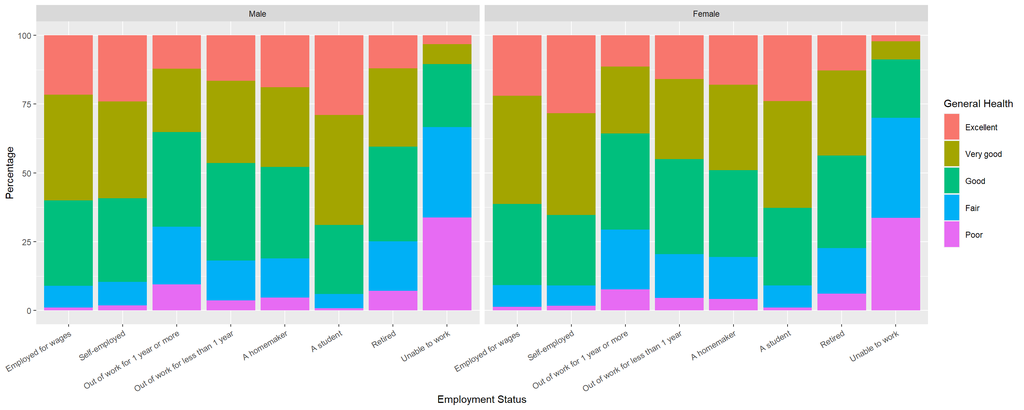

```r
ggplot(q1, aes(x = factor(employ1), y = perc*100, fill = factor(genhlth))) +
 geom_bar(stat="identity") +
  labs(x = "Employment Status", y = "Percentage", fill = "General Health") +
  theme(legend.key.height=unit(1, "cm"),axis.text.x = element_text(angle = 30, hjust=1))+
  facet_grid(. ~  sex)
```

**Research question 2:**

```r
q2 <- brfss2013 %>% select(sex, X_state, genhlth) %>%
  filter(!is.na(sex), !is.na(X_state), !is.na(genhlth)) %>%
  group_by(sex, X_state, genhlth) %>%
  summarise(count=n()) %>%
  mutate(perc=count/sum(count))
```

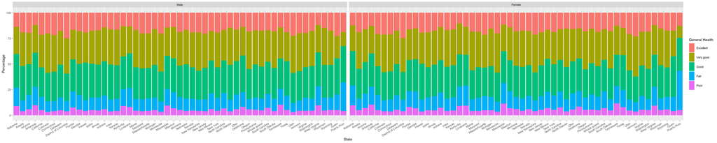

```r
ggplot(q2, aes(x = factor(X_state), y = perc*100, fill = factor(genhlth))) +
 geom_bar(stat="identity") +
  labs(x = "State", y = "Percentage", fill = "General Health") +
  theme(legend.key.height=unit(1, "cm"),axis.text.x = element_text(angle = 30, hjust=1))+
  facet_grid(. ~  sex)
```

**Research question 3:**

```r
q3 <- brfss2013 %>% select(sex, educa, genhlth) %>%
  filter(!is.na(sex), !is.na(educa),!is.na(genhlth)) %>%
  group_by(sex,educa,genhlth) %>%
  summarise(count=n()) %>%
  mutate(perc=count/sum(count))
group_by(q3 , genhlth) %>% summarise(disp=mean(perc))
```

```
## # A tibble: 5 x 2
##   genhlth    disp
## * <fct>     <dbl>
## 1 Excellent 0.130
## 2 Very good 0.237
## 3 Good      0.312
## 4 Fair      0.212
## 5 Poor      0.110
```

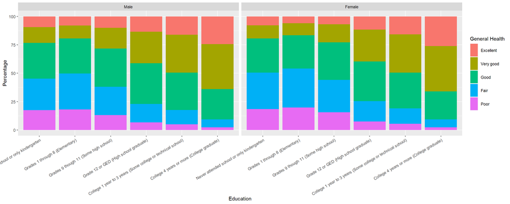

```r
ggplot(q3, aes(x = factor(educa), y = perc*100, fill = factor(genhlth))) +
  geom_bar(stat="identity") +
  labs(x = "Education", y = "Percentage", fill = "General Health") +
  theme(legend.key.height=unit(1, "cm"),axis.text.x = element_text(angle = 30, hjust=1))+
  facet_grid(. ~  sex)
```

The relation between Education and General Health can be easily detected in the graph and it has significant variance.

Findings: 1. Higher Education can lead to more satisfaction from your General Health, as the most satisfied people are the one with Higher education or college degree. 2. Lower education or no education increases the chance of not having good feelings about your health. 3. While these findings may sound straight forward, further analysis is needed. For instance, there are chances the the income level would have a confound effect and its correlation with other factors like having access to better health services affect the result.